# Cervus canadensis - Supervised Classification

First Part

Author

Affiliation

Vincent Arnaud

Université du Québec à Chicoutimi, Canada

Last Update

April 8, 2024

# Degradation of the individual information at seven recorder distances from playback speaker

The way the nature of the individual information in the distance call degrades with distance was assessed using Support vector machines (SVMs). SVMs are kernel-based Machine Learning (ML) classifiers introduced by Cortes and Vapnik (1995) and commonly used in ecology and ethology (Cheng et al. 2012; Kvsn et al. 2020; Dezecache et al. 2021; Arnaud et al. 2023). A supervised classification task usually involves splitting a dataset into training and testing sets. Each instance in the training set contains one “target value” (here, the individual) and a feature vector (here, 34 averaged MFCCs and duration). The process is to fit a probabilistic model based on the training set which predicts the target values of the testing set given only the test features.

## Features

As previously, 35 MFCCs were extracted from each call produced by each individual at each distance. As the duration of calls is variable and ML classification approaches require feature vectors of equal length, we averaged MFCCs over time (Lee et al. 2006). Once again, the first MFCC coefficient was discarded. We appended the duration of the call onto the MFCC vector, resulting in a feature vector for each sound analysed of length 35. Although sacrificing dynamic information, this compact representation mitigate the “curse of dimensionality” referring here to issues that arise in ML when the number of observations is small relative to the number of features.

## Performance estimators

To assess the performance of the classifiers, we relied on the standard accuracy which is a performance metric easily interpretable, suitable for balanced datasets and allowing comparison with previous studies. An instance of training and test sets with a 70%-30% distribution leads to a single accuracy value. However, such a performance metric is sensitive to the composition of each set and may underestimate or overestimate the true performance. To minimize this ML well-known problem, a Monte Carlo cross-validation (Xu and Liang 2001) with 1000 iterations was performed. This method creates 1000 random splits of the dataset into training and test sets to induce variations in the composition of the each training/test set instance. For each split, the model is fit to the training set, and accuracy is assessed using the test set. The result is a distribution of 1000 accuracy values whose mean and standard deviation provide robust estimators of performance. We computed also mean values for the confusion matrices.

Prior to the application of SVMs, each feature was standardized by centering it at the mean value and rescaling it using the standard deviation. The main advantage of standardization is to avoid features in larger numeric ranges dominating those in smaller numeric ranges. It is important to use the same scaling and centering parameters for training and testing sets to avoid potential data leakage (Kaufman, Rosset, and Perlich 2011). Indeed, each instance of the training set was scaled before SVM fitting and each test set instance was scaled accordingly, i.e. using the scaling and centering factors from the training stage, before predictions were made.

## Hyperparameter optimization

SVM involves hyperparameter optimization (HPO). The goal of HPO is to find the optimal hyperparameter configuration of a ML algorithm for a given task leading to the best performance.

For each distance, the following hyperparameters were optimized: a) the kernel function (linear, polynomial and radial basis function or RBF), b) for the polynomial kernel function, the `number of degrees` (values between 1 and 4), c) the regularization parameter (or `cost`) `C` (values between -15 and 15), and d) for the radial kernel function, the parameter `gamma` (values between -15 and 15). It is recommended to tune `cost` and `gamma` on the logarithmic scale (Hsu, Chang, and Lin 2003). The log transformation emphasizes smaller cost and gamma values but also creates large values. Therefore, the log transformation is used to explore this region of the hyperparameter hyperspace more densely (Hsu, Chang, and Lin 2003). Different methods for exploring the hyperparameter hyperspace are available (Feurer and Hutter 2019). We adopted a Bayesian optimization (also known as *model-based optimization* or MBO) in which an optimization function gradually learns the structure of the hyperparameter hyperspace by gathering information from the previous iterations (Wu et al. 2019). The total number of optimization iterations was 35. Since our hyperparameter space included numeric and categorical parameters with dependencies, we took advantage of a Random Forest regression as surrogate model with expected improvement (EI, Močkus, Tiesis, and Zilinskas (1978)) as infill criterion (also called *acquisition function*) (Bischl et al., n.d.). To improve the speed of the optimization, we parallelize computing by evaluating multiple points per iteration (one on each of the CPU cores used). The method used to sample multiple points was the constant liar strategy (Chevalier and Ginsbourger 2013). To find a hyperparameter configuration that optimizes the classification performance for the calls recorded at each distance, a Monte Carlo cross-validation was also performed but only 100 random stratified splits were used. It would have been extremely time-consuming to perform an 1000-iteration optimization. The performance metric selected for the HPO was accuracy.

We relied on `R` packages `e1071` (Meyer et al. 2023), `caret` (Kuhn 2008) and `mlr` (Bischl et al. 2016; Rhys 2020) for SVM fitting and on `mlrMBO` (Bischl et al., n.d.) package for Bayesian hyperparameter optimization. `parallelMap` (Bischl, Lang, and Schratz 2021) package was also used for parallelization of the HPO. The `R` code was adapted and extended from a step-by-step SVM demo proposed by Arnaud et al. (2023).

# First sketch: SVM taking 12 m as a reference

At first, we tested a model where the calls recorded at 12 m where used as a reference for analyzing calls recorded at all other distances.

In this task, the model was trained with 1000 instances of stratified training sets composed of 70% of each individual’s calls (i.e. 7 calls per individual) recorded at 12 m. The discriminative power of this model was then tested, in turn on 1000 instances of stratified test sets made up of 30% of each individual’s calls (i.e. 3 calls per individual) recorded at each of the seven distances considered. Whatever the distance, the individual calls included in a specific instance of the training sets were always different from those present in the corresponding instance of the test sets. Thus, if the model was trained using Bernard’s first seven calls recorded at 12 m, the test set included the last three calls emitted by Bernard at 25 m, for example.

## Mean Accuracies

The highest accuracy (92.72%, ± 4.54% SD) in this 10-class task was obtained using test samples composed of data recorded at 12 m, confirming that wapiti do indeed exhibit an robust individual vocal signature. The accuracies tend to stay stable between 25 and 200 m with values between 77.09 et 83.68% and decrease strongly at 400 and 800 m with a minimum accuracy of 31.54% ± 8.14% SD at 800 m.

| Distance (m) | Mean Accuracy | Standard Deviation |
| --- | --- | --- |
| 12 | 0.9272 | 0.0455 |
| 25 | 0.8369 | 0.0561 |
| 50 | 0.8214 | 0.0618 |
| 100 | 0.7749 | 0.0679 |
| 200 | 0.7710 | 0.0675 |
| 400 | 0.4565 | 0.0797 |
| 800 | 0.3153 | 0.0815 |

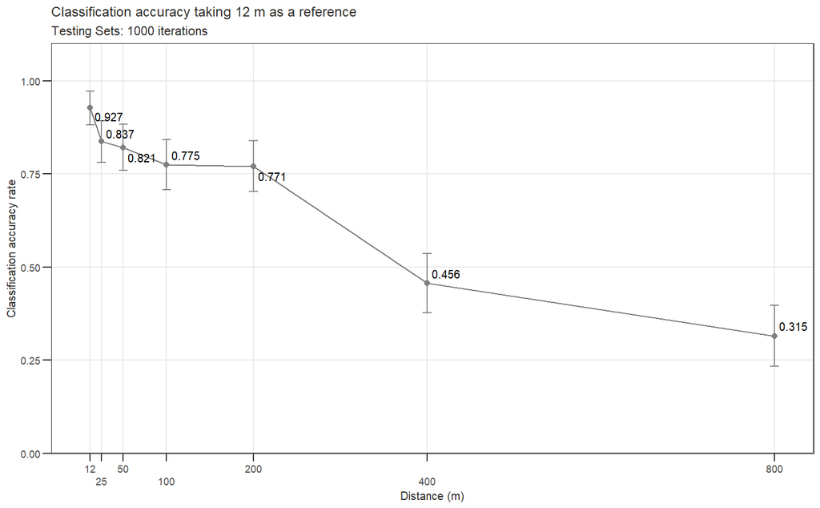

## Confusion Matrices Visualizations

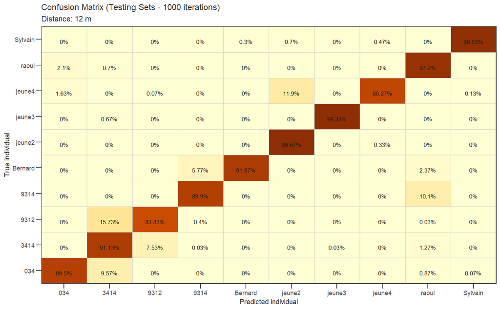

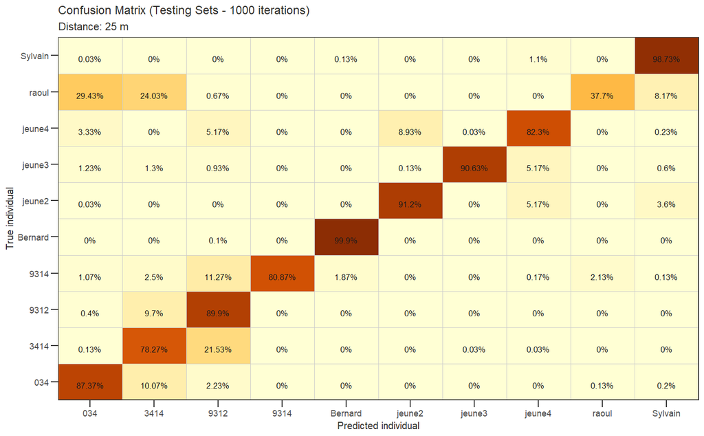

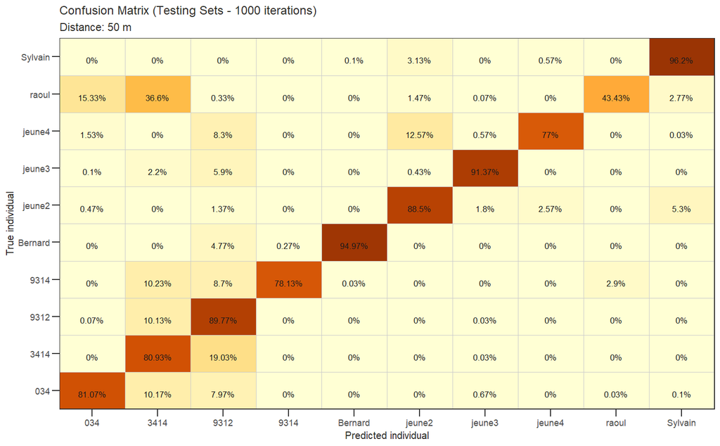

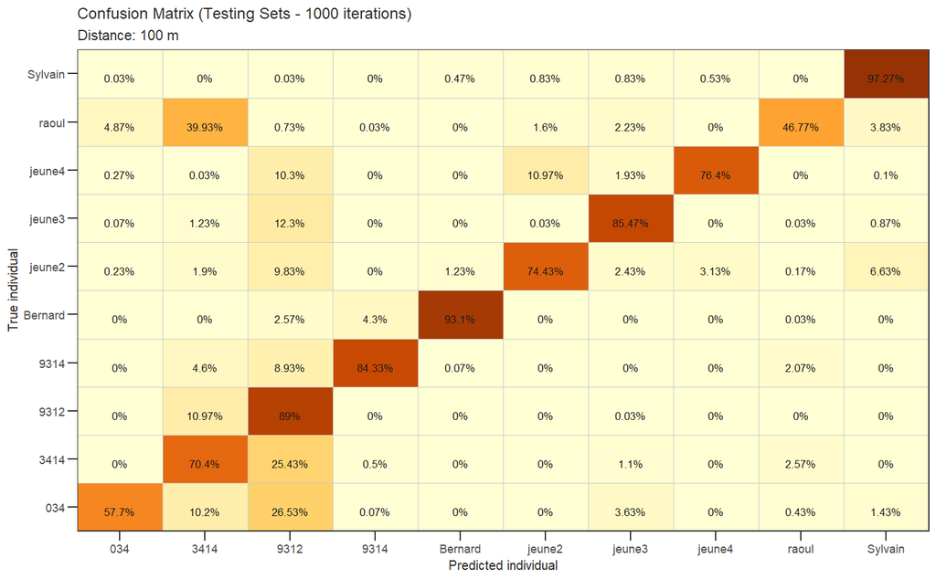

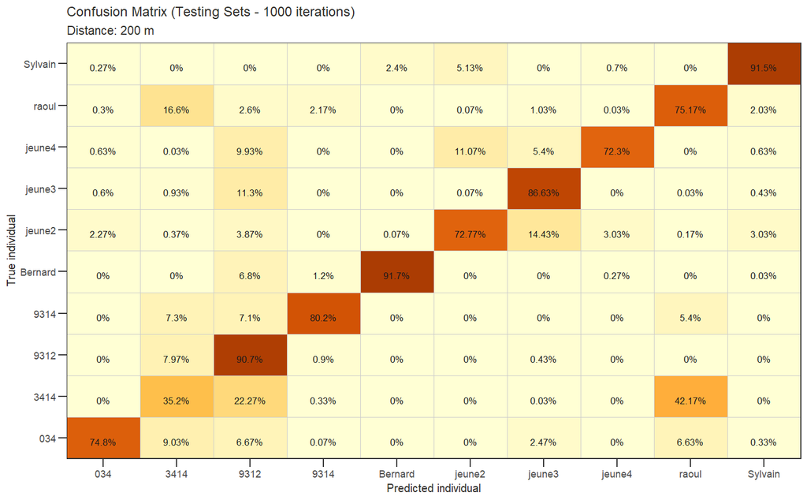

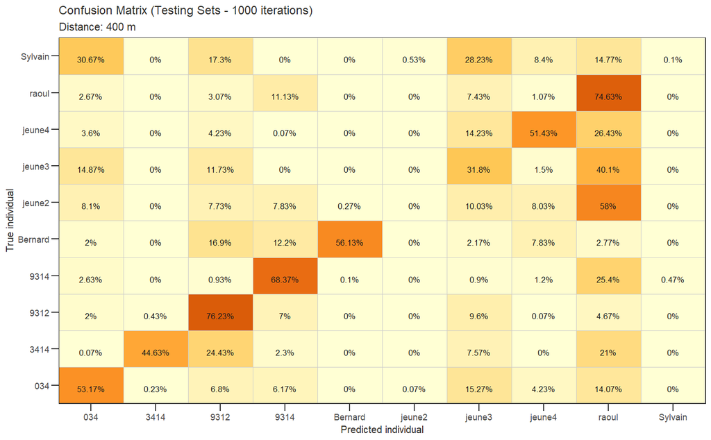

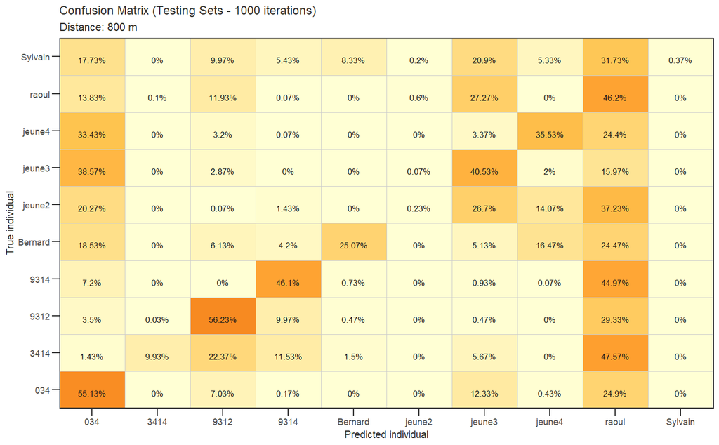

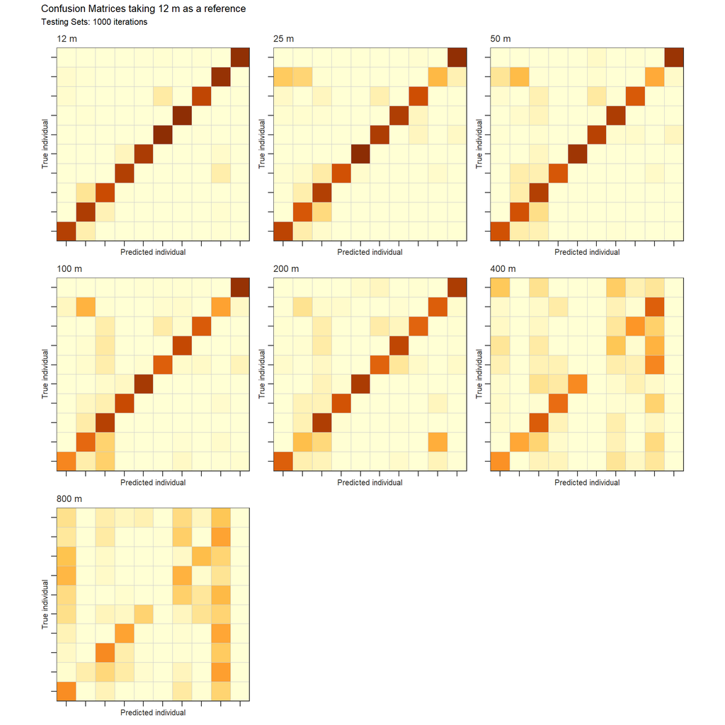

# Second skech: SVMs for each distance separately

In this second scenario, we analyzed the data separately for each distance. This analysis simulated a scenario where the wapiti could use the actual distance of the sound source as independent information to discriminate individuals.

In this task, for each of the seven distances considered separately, a model was trained with 1000 instances of stratified training sets composed of 70% of each individual’s calls (i.e. 7 calls per individual) then tested on 1000 instances of stratified test sets made up of 30% of each individual’s calls (i.e. 3 calls per individual).

## Mean Accuracies

| Distance (m) | Mean Accuracy | Standard Deviation |
| --- | --- | --- |
| 12 | 0.9291 | 0.0432 |
| 25 | 0.9278 | 0.0426 |
| 50 | 0.9207 | 0.0460 |
| 100 | 0.9056 | 0.0489 |
| 200 | 0.8989 | 0.0539 |
| 400 | 0.8326 | 0.0650 |
| 800 | 0.7839 | 0.0700 |

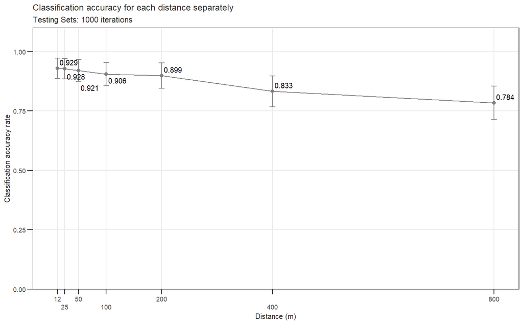

## Confusion Matrices Visualizations

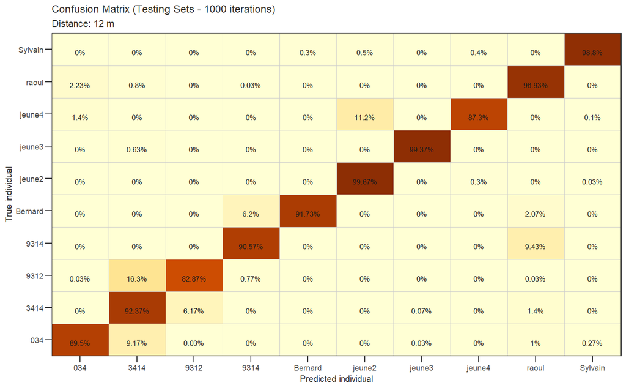

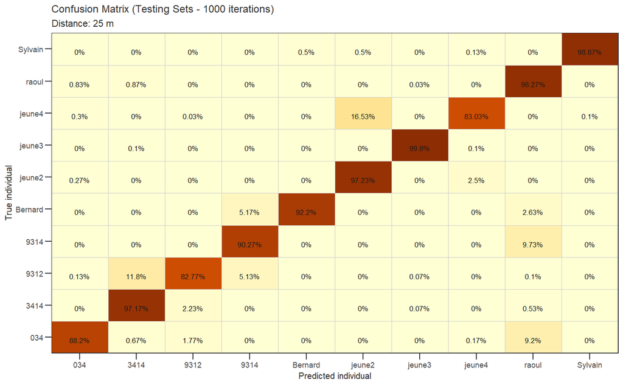

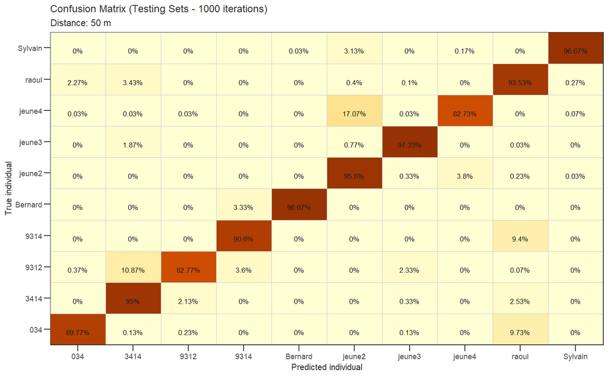

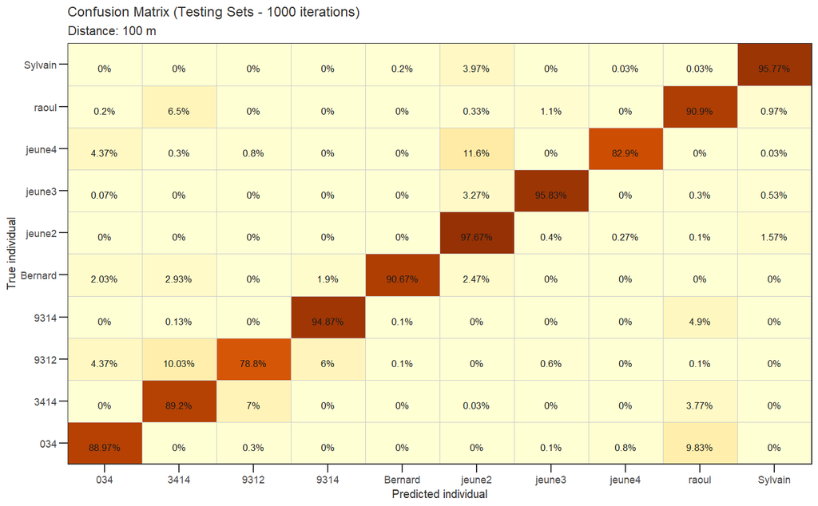

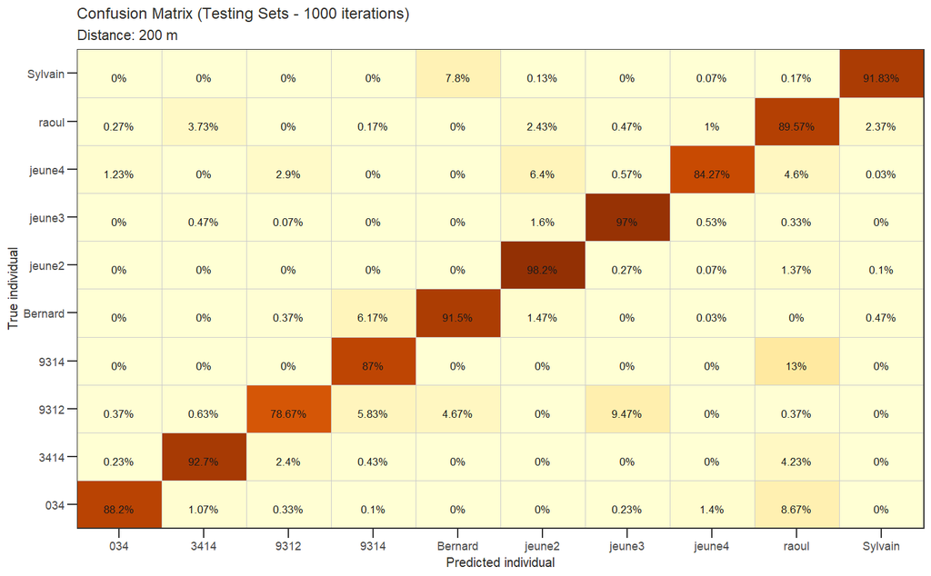

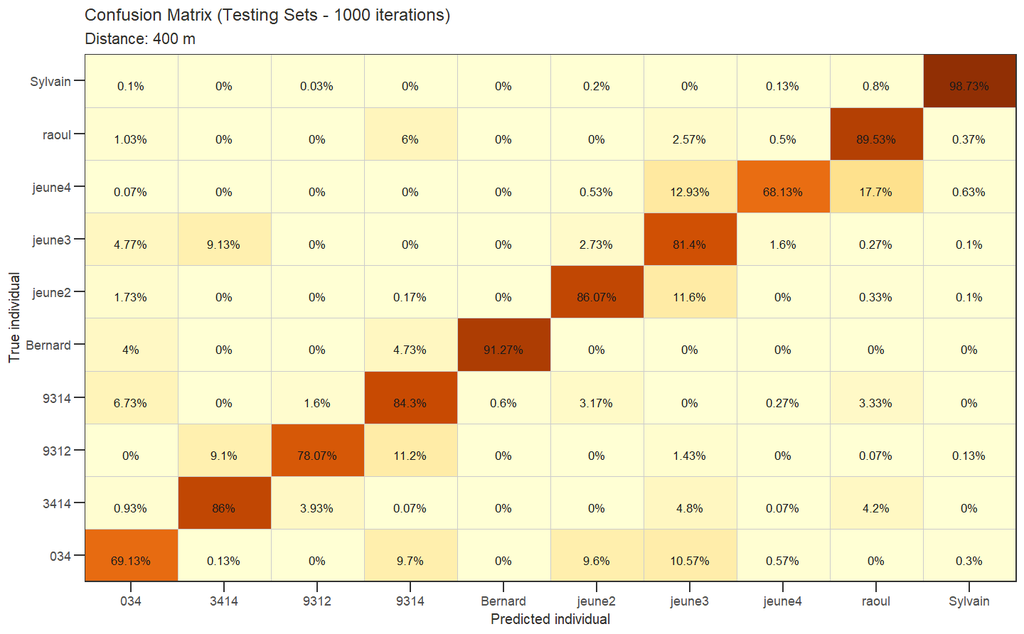

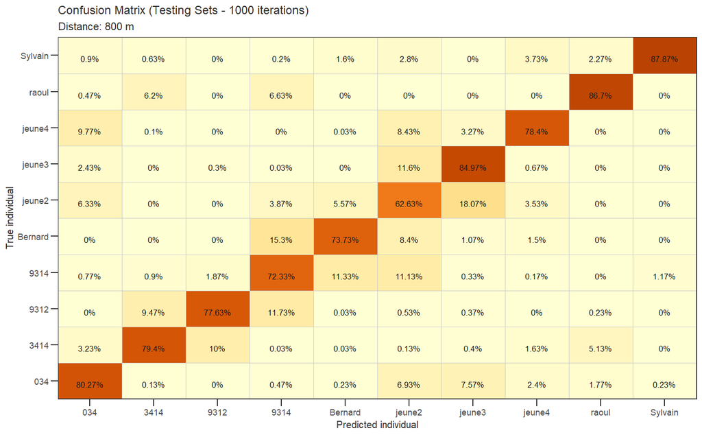

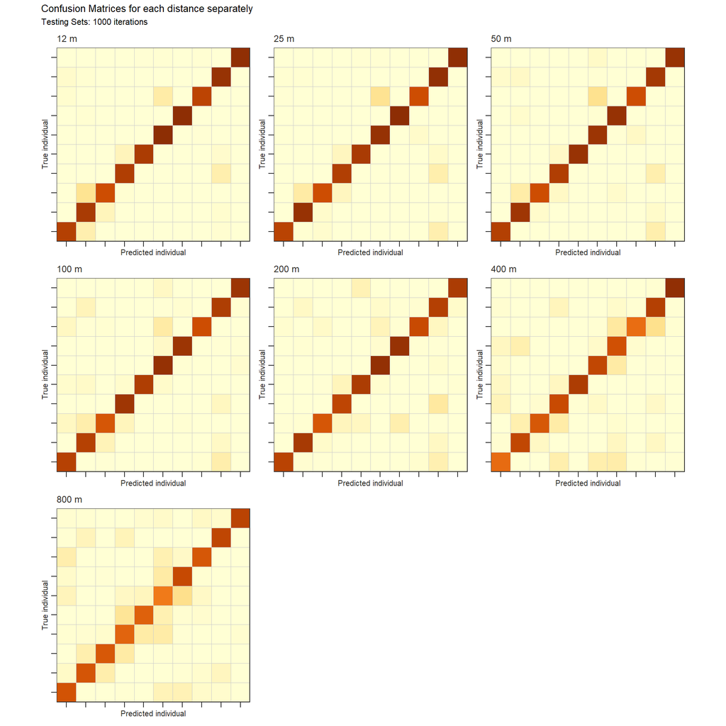

# Third skech: A Data Leakage Sketch?

In this scenario, SVMs were trained using, in turn, the data available at each distance. Each of these models was then tested for each of the seven distances considered.

The following figure illustrates that, in such a scenario, accuracy is always higher if training and test data used were recorded at the same distance.

> The aim here is to discriminate a possible acoustic identity or the complete acoustic environment present at every distance from the source?

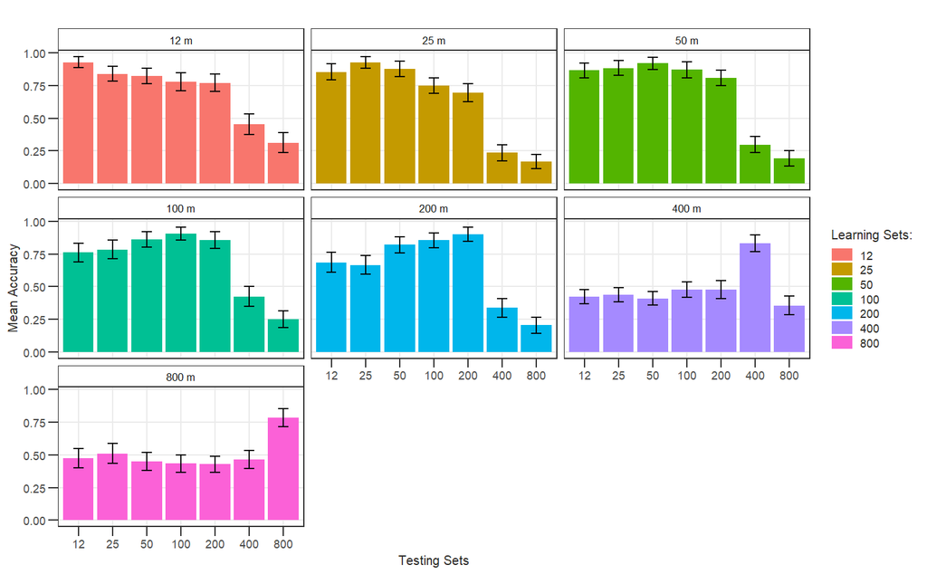

## References

Arnaud, Vincent, François Pellegrino, Sumir Keenan, Xavier St-Gelais, Nicolas Mathevon, Florence Levréro, and Christophe Coupé. 2023. “Improving the Workflow to Crack Small, Unbalanced, Noisy, but Genuine (SUNG) Datasets in Bioacoustics: The Case of Bonobo Calls.” *PLOS Computational Biology* 19 (4): e1010325. https://doi.org/10.1371/journal.pcbi.1010325.

Bischl, Bernd, Michel Lang, Lars Kotthoff, Julia Schiffner, Jakob Richter, Erich Studerus, Giuseppe Casalicchio, and Zachary M. Jones. 2016. “Mlr: Machine Learning in r.” *Journal of Machine Learning Research* 17 (170): 1–5.

Bischl, Bernd, Michel Lang, and Patrick Schratz. 2021. “parallelMap: Unified Interface to Parallelization Back-Ends.” https://CRAN.R-project.org/package=parallelMap.

Bischl, Bernd, Jakob Richter, Jakob Bossek, Daniel Horn, Janek Thomas, and Michel Lang. n.d. “mlrMBO: A Modular Framework for Model-Based Optimization of Expensive Black-Box Functions.” https://doi.org/10.48550/arXiv.1703.03373.

Cheng, Jinkui, Bengui Xie, Congtian Lin, and Liqiang Ji. 2012. “A Comparative Study in Birds: Call-Type-Independent Species and Individual Recognition Using Four Machine-Learning Methods and Two Acoustic Features.” *Bioacoustics* 21 (2): 157–71. https://doi.org/10.1080/09524622.2012.669664.

Chevalier, Clément, and David Ginsbourger. 2013. “Fast Computation of the Multi-Points Expected Improvement with Applications in Batch Selection.” In, edited by Giuseppe Nicosia and Panos Pardalos, 59–69. Berlin, Heidelberg: Springer. https://doi.org/10.1007/978-3-642-44973-4_7.

Cortes, Corinna, and Vladimir Vapnik. 1995. “Support-Vector Networks.” *Machine Learning* 20 (3): 273–97. https://doi.org/10.1007/BF00994018.

Dezecache, Guillaume, Klaus Zuberbühler, Marina Davila-Ross, and Christoph D. Dahl. 2021. “A Machine Learning Approach to Infant Distress Calls and Maternal Behaviour of Wild Chimpanzees.” *Animal Cognition* 24 (3): 443–55. https://doi.org/10.1007/s10071-020-01437-5.

Feurer, Matthias, and Frank Hutter. 2019. “Hyperparameter Optimization.” In, edited by Frank Hutter, Lars Kotthoff, and Joaquin Vanschoren, 3–33. Cham: Springer.

Hsu, Chih-wei, Chih-chung Chang, and Chih-Jen Lin. 2003. “A Practical Guide to Support Vector Classification.” https://www.csie.ntu.edu.tw/~cjlin/papers/guide/guide.pdf.

Kaufman, Shachar, Saharon Rosset, and Claudia Perlich. 2011. “KDD ’11: The 17th ACM SIGKDD International Conference on Knowledge Discovery and Data Mining.” In, 556–63. San Diego: ACM. https://doi.org/10.1145/2020408.2020496.

Kuhn, Max. 2008. “Building Predictive Models in r Using the Caret Package.” *Journal of Statistical Software* 28 (5). https://doi.org/10.18637/jss.v028.i05.

Kvsn, Rama Rao, James Montgomery, Saurabh Garg, and Michael Charleston. 2020. “Bioacoustics Data Analysis a Taxonomy, Survey and Open Challenges.” *IEEE Access* 8: 57684–708. https://doi.org/10.1109/ACCESS.2020.2978547.

Lee, Chang-Hsing, Chih-Hsun Chou, Chin-Chuan Han, and Ren-Zhuang Huang. 2006. “Automatic Recognition of Animal Vocalizations Using Averaged MFCC and Linear Discriminant Analysis.” *Pattern Recognition Letters* 27 (2): 93–101. https://doi.org/10.1016/j.patrec.2005.07.004.

Meyer, David, Evgenia Dimitriadou, Kurt Hornik, Andreas Weingessel, and Friedrich Leisch. 2023. “E1071: Misc Functions of the Department of Statistics, Probability Theory Group (Formerly: E1071), TU Wien.” https://CRAN.R-project.org/package=e1071.

Močkus, J., Vytautas Tiesis, and Antanas Zilinskas. 1978. “The Application of Bayesian Methods for Seeking the Extremum.” In, edited by L. C. W. Dixon and G. P. Szegö, 2:117–29. Amsterdam: North-Holand.

Rhys, Hefin. 2020. *Machine Learning with r, Tidyverse, and Mlr*. Shelter Island, États-Unis: Manning Publications.

Wu, Jia, Xiu-Yun Chen, Hao Zhang, Li-Dong Xiong, Hang Lei, and Si-Hao Deng. 2019. “Hyperparameter Optimization for Machine Learning Models Based on Bayesian Optimization.” *Journal of Electronic Science and Technology* 17 (1): 26–40. https://doi.org/10.11989/JEST.1674-862X.80904120.

Xu, Qing-Song, and Yi-Zeng Liang. 2001. “Monte Carlo Cross Validation.” *Chemometrics and Intelligent Laboratory Systems* 56 (1): 1–11. https://doi.org/10.1016/S0169-7439(00)00122-2.